# Lab 5 Inverse Distance Weighting

## 5.1 IDW from Scratch

Inverse distance weighting (IDW) is one of the simplest deterministic spatio-temporal interpolation methods. It can be implemented easily in R using the function `idw` in the package `gstat`.

```r
library("gstat")
library("sp")
library("spacetime")
library("STRbook")
library("fields")
library("tidyverse")
```

We consider the maximum temperature field in the NOAA data set for the month of July 1993. These data can be obtained from the data `NOAA_df_1990` using the `filter` function.

```r
data("NOAA_df_1990", package = "STRbook")
Tmax <- filter(NOAA_df_1990, # subset the data
               proc == "Tmax" & # only max temperature
                 month == 7 & # July
                 year == 1993) # year of 1993
```

We next construct the three-dimensional spatio-temporal prediction grid using `expand.grid`. We consider a 20 × 20 grid in longitude and latitude and a sequence of 6 days regularly arranged in the month.

```r
pred_grid <- expand.grid(lon = seq(-100, -80, length = 20),
                         lat = seq(32, 46, length = 20),
                         day = seq(4, 29, length = 6))
pred_grid
```

| lon | lat | day |
| --- | --- | --- |
| -100.00000 | 32.00000 | 4 |
| -98.94737 | 32.00000 | 4 |
| -97.89474 | 32.00000 | 4 |
| -96.84211 | 32.00000 | 4 |
| -95.78947 | 32.00000 | 4 |
| -94.73684 | 32.00000 | 4 |
| -93.68421 | 32.00000 | 4 |
| -92.63158 | 32.00000 | 4 |
| -91.57895 | 32.00000 | 4 |
| -90.52632 | 32.00000 | 4 |

[output cut: 990 more lines]

```r
Tmax_no_14 <- filter(Tmax, !(day == 14)) # remove day 14
Tmax_14 <- filter(Tmax, day == 14) %>% select(lon,lat,z) # retain day 14 only
```

To construct these kernel weights we first need to find the distances between all prediction locations and data locations, take their reciprocals and raise them to the power (`idp`) of $α$.

Pairwise distances between two arbitrary sets of points are most easily computed using the `rdist` function in the package `fields`. Since we wish to generate these kernel weights for different observation and prediction sets and different bandwidth parameters, we create a function `Wt_IDW` that generates the required kernel-weights matrix.

```r
pred_obs_dist_mat <- rdist(select(pred_grid, lon, lat, day),
                           select(Tmax_no_14, lon, lat, day))

Wt_IDW <- function(theta, dist_mat) 1/dist_mat^theta

Wtilde <- Wt_IDW(theta = 5, dist_mat = pred_obs_dist_mat)
```

The matrix `Wtilde` now contains all the $\tilde{w_{ij}}$; that is, the $(k,l)$th element in `Wtilde` contains the distance between the $k$th prediction location and the $l$th observation location, raised to the power of $5$, and reciprocated.

Next, we compute the weights which are just the kernel weights normalized by the sum of all kernel weights associated with each prediction location. Normalizing the weights at every location can be done easily using `rowSums` in R.

```r
Wtilde_rsums <- rowSums(Wtilde)
W <- Wtilde/Wtilde_rsums
```

The predictions are then given by multiplying `W` by the data.

```r
z_pred_IDW <- as.numeric(W %*% Tmax_no_14$z)

z_pred_IDW <- data.frame(pred=z_pred_IDW,lon=Tmax_July_idw$lon, lat=Tmax_July_idw$lat)
```

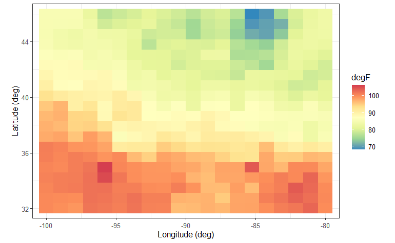

```r
ggplot(z_pred_IDW) +
  geom_tile(aes(x = lon, y = lat,
                fill = pred)) +
  fill_scale(name = "degF") + # attach color scale
  xlab("Longitude (deg)") + # x-axis label
  ylab("Latitude (deg)") + # y-axis label
  coord_fixed(xlim = c(-100, -80),
              ylim = c(32, 46)) + # zoom in
  theme_bw() # B&W theme
```

```r
z_pred_IDW
```

| pred | lon | lat |
| --- | --- | --- |
| 94.95263 | -100.00000 | 32.00000 |
| 93.14461 | -98.94737 | 32.00000 |
| 92.00611 | -97.89474 | 32.00000 |
| 93.48878 | -96.84211 | 32.00000 |
| 93.35167 | -95.78947 | 32.00000 |
| 91.78064 | -94.73684 | 32.00000 |
| 91.10593 | -93.68421 | 32.00000 |
| 92.85079 | -92.63158 | 32.00000 |
| 92.99021 | -91.57895 | 32.00000 |
| 92.10476 | -90.52632 | 32.00000 |

[output cut: 990 more lines]

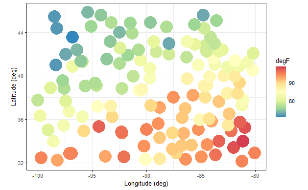

```r
ggplot(Tmax_14) +
  geom_point(aes(x = lon, y = lat, col = z), size=10) +
  col_scale(name = "degF") + # attach color scale
  xlab("Longitude (deg)") + # x-axis label
  ylab("Latitude (deg)") + # y-axis label
  coord_fixed(xlim = c(-100, -80),
              ylim = c(32, 46)) + # zoom in
  theme_bw() # B&W theme
```

```r
Tmax_14
```

| lon | lat | z |
| --- | --- | --- |
| -81.20000 | 32.13334 | 95 |
| -98.18333 | 32.21667 | 93 |
| -86.40000 | 32.30000 | 94 |
| -90.08334 | 32.31667 | 85 |
| -88.75000 | 32.33333 | 88 |
| -99.68333 | 32.43333 | 95 |
| -92.05000 | 32.51667 | 96 |
| -84.93333 | 32.51667 | 94 |
| -93.76667 | 32.55000 | 93 |
| -83.65000 | 32.70000 | 96 |

[output cut: 123 more lines]

We can change the kernel function to whatever we want and compare predictions from different kernel functions. We implement a kernel smoother below, where the kernel is a Gaussian radial basis function with $θ = 0.5$.

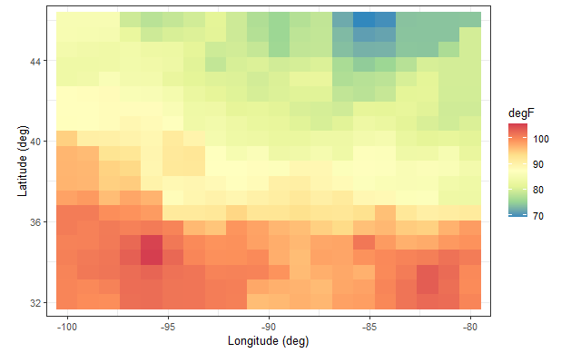

```r
theta <- 0.5 # set bandwidth
Wt_Gauss <- function(theta, dist_mat) exp(-dist_mat^2/theta)

Wtilde <- Wt_Gauss(theta = 0.5, dist_mat = pred_obs_dist_mat)
Wtilde_rsums <- rowSums(Wtilde) # normalizing factors
W <- Wtilde/Wtilde_rsums # normalized kernel weights
z_pred2 <- W %*% Tmax_no_14$z # predictions

z_pred2 <- data.frame(pred=z_pred2,lon=Tmax_July_idw$lon, lat=Tmax_July_idw$lat)

ggplot(z_pred2) +
  geom_tile(aes(x = lon, y = lat,
                fill = pred)) +
  fill_scale(name = "degF") + # attach color scale
  xlab("Longitude (deg)") + # x-axis label
  ylab("Latitude (deg)") + # y-axis label
  coord_fixed(xlim = c(-100, -80),
              ylim = c(32, 46)) + # zoom in
  theme_bw() # B&W theme
```

## 5.2 Cross-Validation

To carry out CV, we need to fit the model using a subset of the data (known as the training set), predict at the data locations that were omitted (known as the validation set), and compute a discrepancy, usually the squared error, between the predicted and observed values. If we leave one data point out at a time, the procedure is known as leave-one out cross-validation (LOOCV).

The simplest way to do LOOCV in this context is to compute the pairwise distances between all observation locations and the associated kernel-weight matrix, and then to select the appropriate rows and columns from the resulting matrix to do prediction at a left-out observation; this is repeated for every observation.

The distances between all observations are computed as follows.

```r
obs_obs_dist_mat <- rdist(select(Tmax, lon, lat, day),
                          select(Tmax, lon, lat, day))
```

A function that computes the LOOCV score is given as follows.

```r
LOOCV_score <- function(Wt_fun, theta, dist_mat, Z){
  Wtilde <- Wt_fun(theta, dist_mat)
  CV <- 0
  for(i in 1:length(Z)) {
    Wtilde2 <- Wtilde[i,-i]
    W2 <- Wtilde2 / sum(Wtilde2)
    z_pred <- W2 %*% Z[-i]
    CV[i] <- (z_pred - Z[i])^2
  }
  mean(CV)
}
```

The function first constructs the kernel-weights matrix for the given bandwith. Then, for the $i$th observation, it selects the $i$th row and excludes the $i$th column from the kernel-weights matrix and assigns the resulting vector to `Wtilde2`. This vector contains the kernel weights for the $i$th observation location (which is now a prediction location) with the weights contributed by this $i$th observation removed. This vector is normalized and then cross-multiplied with the data to yield the prediction. This is done for all $i = 1, ... , n$, and then the mean of the squared errors is returned. To see which of the two predictors is “better,” we now simply call `LOOCV_score` with the two different kernel functions and bandwidths.

```r
LOOCV_score(Wt_fun = Wt_IDW,
            theta = 5,
            dist_mat = obs_obs_dist_mat,
            Z = Tmax$z)
```

```
[1] 7.775333
```

```r
## [1] 7.78
LOOCV_score(Wt_fun = Wt_Gauss,
            theta = 0.5,
            dist_mat = obs_obs_dist_mat,
            Z = Tmax$z)
```

```
[1] 7.526056
```

```r
## [1] 7.53
```

An objective way to set the bandwidth parameters is done by computing `LOOCV_score` for a set, say 21, of plausible bandwidths and finding the minimum. We do this below for both IDW and the Gaussian kernel.

```r
theta_IDW <- seq(4, 6, length = 21)
theta_Gauss <- seq(0.1, 2.1, length = 21)
CV_IDW <- CV_Gauss <- 0
for(i in seq_along(theta_IDW)) {
  CV_IDW[i] <- LOOCV_score(Wt_fun = Wt_IDW,
                           theta = theta_IDW[i],
                           dist_mat = obs_obs_dist_mat,
                           Z = Tmax$z)
  CV_Gauss[i] <- LOOCV_score(Wt_fun = Wt_Gauss,
                             theta = theta_Gauss[i],
                             dist_mat = obs_obs_dist_mat,
                             Z = Tmax$z)
}
```

The plots showing the LOOCV scores as a function of $α$ and $θ$ for the IDW and Gaussian kernels, respectively, exhibit clear minima when plotted, which is very typical of plots of this kind.

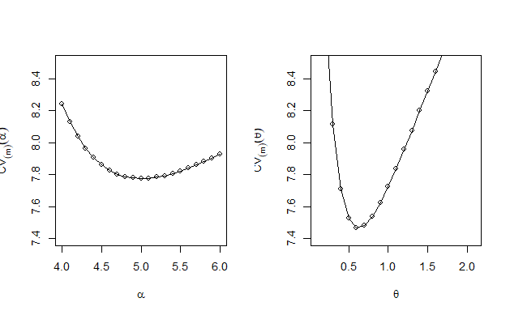

```r
par(mfrow = c(1,2))
plot(theta_IDW, CV_IDW,
     xlab = expression(alpha),
     ylab = expression(CV[(m)](alpha)),
     ylim = c(7.4, 8.5), type = 'o')
plot(theta_Gauss, CV_Gauss,
     xlab = expression(theta),
     ylab = expression(CV[(m)](theta)),
     ylim = c(7.4, 8.5), type = 'o')
```

The optimal inverse-power and minimum LOOCV score for IDW are

```r
theta_IDW[which.min(CV_IDW)]
```

```
[1] 5
```

```r
## [1] 5
min(CV_IDW)
```

```
[1] 7.775333
```

```r
## [1] 7.78
```

The optimal bandwidth and minimum LOOCV score for the Gaussian kernel smoother are

```r
theta_Gauss[which.min(CV_Gauss)]
```

```
[1] 0.6
```

```r
## [1] 0.6
min(CV_Gauss)
```

```
[1] 7.468624
```

```r
## [1] 7.47
```